# Write a Jupyter Notebook explaining all the Descriptive Statistics.

# Mean

# Median

# Mode

# Variance

# Standard Deviation

# Correlation

# Normal Distribution (use references)

# Feature of Normal Distribution

# Positively Skewed & Negatively Skewed Normal Distribution

# Effect on Mean, Median and Mode due to Skewness

# Explain QQ Plot and show the implementation of the same

# Explain Box Cox and show the implementation of the same

# MEAN

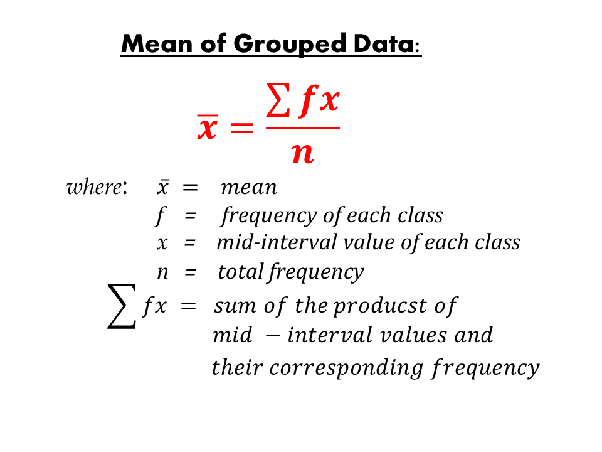

# Importing the libraries

```python
import pandas as pd
import numpy as np
import seaborn as sns
from scipy import stats
import matplotlib.pyplot as plt
from scipy.stats import boxcox
import warnings
warnings.filterwarnings('ignore')
from scipy.stats import norm
```

# Reading the data

```python
# Reading the data given
data = pd.read_csv("data.csv")
```

# Understanding the data

```python
# checking the dimensions of the data
data.shape
```

```
(50, 7)
```

```python
# checking the first five and last five records
data.head(5)
```

|  | Mthly_HH_Income | Mthly_HH_Expense | No_of_Fly_Members | Emi_or_Rent_Amt | Annual_HH_Income | Highest_Qualified_Member | No_of_Earning_Members |
| --- | --- | --- | --- | --- | --- | --- | --- |
| 0 | 5000 | 8000 | 3 | 2000 | 64200 | Under-Graduate | 1 |
| 1 | 6000 | 7000 | 2 | 3000 | 79920 | Illiterate | 1 |
| 2 | 10000 | 4500 | 2 | 0 | 112800 | Under-Graduate | 1 |
| 3 | 10000 | 2000 | 1 | 0 | 97200 | Illiterate | 1 |
| 4 | 12500 | 12000 | 2 | 3000 | 147000 | Graduate | 1 |

```python
# last five records
data.tail(5)
```

|  | Mthly_HH_Income | Mthly_HH_Expense | No_of_Fly_Members | Emi_or_Rent_Amt | Annual_HH_Income | Highest_Qualified_Member | No_of_Earning_Members |
| --- | --- | --- | --- | --- | --- | --- | --- |
| 45 | 90000 | 48000 | 7 | 0 | 885600 | Post-Graduate | 3 |
| 46 | 98000 | 25000 | 5 | 0 | 1152480 | Professional | 2 |
| 47 | 100000 | 30000 | 6 | 0 | 1404000 | Graduate | 3 |
| 48 | 100000 | 50000 | 4 | 20000 | 1032000 | Professional | 2 |
| 49 | 100000 | 40000 | 6 | 10000 | 1320000 | Post-Graduate | 1 |

# Summary statistics

```python
data.describe().T
```

|  | count | mean | std | min | 25% | 50% | 75% | max |
| --- | --- | --- | --- | --- | --- | --- | --- | --- |
| Mthly_HH_Income | 50.0 | 41558.00 | 26097.908979 | 5000.0 | 23550.0 | 35000.0 | 50375.0 | 100000.0 |
| Mthly_HH_Expense | 50.0 | 18818.00 | 12090.216824 | 2000.0 | 10000.0 | 15500.0 | 25000.0 | 50000.0 |
| No_of_Fly_Members | 50.0 | 4.06 | 1.517382 | 1.0 | 3.0 | 4.0 | 5.0 | 7.0 |
| Emi_or_Rent_Amt | 50.0 | 3060.00 | 6241.434948 | 0.0 | 0.0 | 0.0 | 3500.0 | 35000.0 |
| Annual_HH_Income | 50.0 | 490019.04 | 320135.792123 | 64200.0 | 258750.0 | 447420.0 | 594720.0 | 1404000.0 |
| No_of_Earning_Members | 50.0 | 1.46 | 0.734291 | 1.0 | 1.0 | 1.0 | 2.0 | 4.0 |

# Mean

```python
data.mean()
```

```
Mthly_HH_Income           41558.00
Mthly_HH_Expense          18818.00
No_of_Fly_Members             4.06
Emi_or_Rent_Amt            3060.00
Annual_HH_Income         490019.04
No_of_Earning_Members         1.46
dtype: float64
```

# Median

Median is the point which divides the data point into the equal halves. The median is calculated by following steps: 1.First sort the data in ascending order. 2.If the number of observations are odd, median is given by the middle observation. 3.If the number of observations are even, median is given by the mean of the two middle observation.

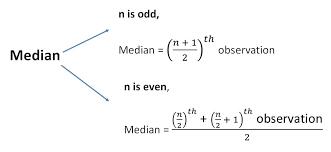

```python
# Now finding the median of every attribute in the data

data.median()
```

```
Mthly_HH_Income           35000.0
Mthly_HH_Expense          15500.0
No_of_Fly_Members             4.0
Emi_or_Rent_Amt               0.0
Annual_HH_Income         447420.0
No_of_Earning_Members         1.0
dtype: float64
```

# Mode

The mode is a statistical term that refers to the most frequently occurring number found in a set of numbers.

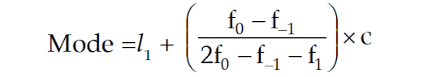

```python
cat_attr=['No_of_Fly_Members','Emi_or_Rent_Amt','No_of_Earning_Members']
```

```python
data[cat_attr]=data[cat_attr].astype('category')
```

```python
data[cat_attr].mode()
```

|  | No_of_Fly_Members | Emi_or_Rent_Amt | No_of_Earning_Members |
| --- | --- | --- | --- |
| 0 | 4 | 0 | 1 |

# variance

variance is a measure of dispersion that takes into account the spread of all data points in a data set. The variance is mean squared difference between each data point and the centre of the distribution measured by the mean.

Formula:

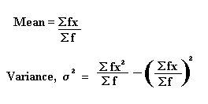

```python
# finding the variance of the given data

data.var()
```

```
Mthly_HH_Income          6.811009e+08
Mthly_HH_Expense         1.461733e+08
No_of_Fly_Members        2.302449e+00
Emi_or_Rent_Amt          3.895551e+07
Annual_HH_Income         1.024869e+11
No_of_Earning_Members    5.391837e-01
dtype: float64
```

# Standard deviation

In statistics, the standard deviation is a measure of the amount of variation or dispersion of a set of values. A low standard deviation indicates that the values tend to be close to the mean (also called the expected value) of the set, while a high standard deviation indicates that the values are spread out over a wider range.

population standard deviation is equal to the square root of the variance.

[figure not shown]

```python
#calculating standard deviation for the given data

data.std()
```

```
Mthly_HH_Income           26097.908979
Mthly_HH_Expense          12090.216824
No_of_Fly_Members             1.517382
Emi_or_Rent_Amt            6241.434948
Annual_HH_Income         320135.792123
No_of_Earning_Members         0.734291
dtype: float64
```

# Correlation

Correlation is a statistical measure that expresses the extent to which two variables are linearly related (meaning they change together at a constant rate). It's a common tool for describing simple relationships without making a statement about cause and effect.

[figure not shown]

```python
# Finding the correlation in the given data

data.corr()
```

|  | Mthly_HH_Income | Mthly_HH_Expense | Annual_HH_Income |
| --- | --- | --- | --- |
| Mthly_HH_Income | 1.000000 | 0.649215 | 0.970315 |
| Mthly_HH_Expense | 0.649215 | 1.000000 | 0.591222 |
| Annual_HH_Income | 0.970315 | 0.591222 | 1.000000 |

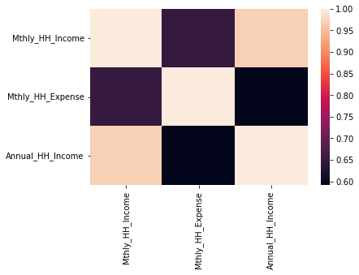

```python
# generating heat map for correlation
sns.heatmap(data.corr())
```

# Normal Distribution

▪Mean = Median = Mode

▪Zero Skew and Kurtosis

▪Shaded area gives the probability that X is between the corresponding values

▪68 95 99.7 empirical rule

Normal distribution, also known as the Gaussian distribution, is a probability distribution that is symmetric about the mean, showing that data near the mean are more frequent in occurrence than data far from the mean. In graph form, normal distribution will appear as a bell curve.

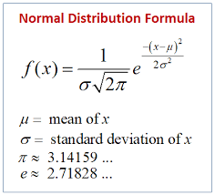

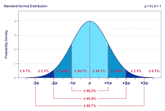

# Features of Normal Distribution

Normal distributions have key characteristics that are easy to spot in graphs: 1.The mean, median and mode are exactly the same. 2.The distribution is symmetric about the mean—half the values fall below the mean and half above the mean. 3.The distribution can be described by two values: the mean and the standard deviation.

```python
# checking the normal distribution of data

from sklearn.preprocessing import StandardScaler
data_std=StandardScaler()
```

```python
data.columns
```

```
Index(['Mthly_HH_Income', 'Mthly_HH_Expense', 'No_of_Fly_Members',
       'Emi_or_Rent_Amt', 'Annual_HH_Income', 'Highest_Qualified_Member',
       'No_of_Earning_Members'],
      dtype='object')
```

```python
num_attr=['Mthly_HH_Income', 'Mthly_HH_Expense',
       'Emi_or_Rent_Amt', 'Annual_HH_Income']
```

```python
data_std.fit(data[num_attr])
```

```
StandardScaler()
```

```python
data_std2=data_std.transform(data[num_attr])
```

```python
data_std2=pd.DataFrame(data_std2, columns=num_attr)
```

```python
data_std2.head()
```

|  | Mthly_HH_Income | Mthly_HH_Expense | Emi_or_Rent_Amt | Annual_HH_Income |
| --- | --- | --- | --- | --- |
| 0 | -1.415024 | -0.903857 | -0.171557 | -1.343624 |
| 1 | -1.376317 | -0.987408 | -0.009711 | -1.294021 |
| 2 | -1.221492 | -1.196287 | -0.495249 | -1.190272 |
| 3 | -1.221492 | -1.405165 | -0.495249 | -1.239496 |
| 4 | -1.124727 | -0.569652 | -0.009711 | -1.082358 |

# Positively Skewed and Negatively Skewed Normal Distribution

What is a Positively Skewed Distribution? In statistics, a positively skewed (or right-skewed) distribution is a type of distribution in which most values are clustered around the left tail of the distribution while the right tail of the distribution is longer

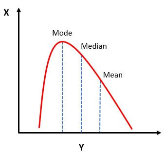

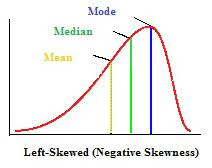

```python
# checking skewness for the columns

data.skew()
```

```
Mthly_HH_Income          0.924615
Mthly_HH_Expense         1.199461
No_of_Fly_Members        0.113674
Emi_or_Rent_Amt          3.403680
Annual_HH_Income         1.192949
No_of_Earning_Members    1.593301
dtype: float64
```

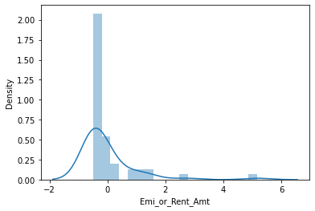

```python
# Skewness for Emi_or_Rent_Amt is high.
# checking the skewness by plotting

sns.distplot(data_std2['Emi_or_Rent_Amt'])
```

# Effect on Mean, Median and Mode due to Skewness

To summarize, generally if the distribution of data is skewed to the left, the mean is less than the median, which is often less than the mode. If the distribution of data is skewed to the right, the mode is often less than the median, which is less than the mean.

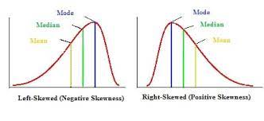

# Q-Q Plot and implementation of the Same

The quantile-quantile (q-q) plot is a graphical technique for determining if two data sets come from populations with a common distribution. A q-q plot is a plot of the quantiles of the first data set against the quantiles of the second data set. By a quantile, we mean the fraction (or percent) of points below the given value. That is, the 0.3 (or 30%) quantile is the point at which 30% percent of the data fall below and 70% fall above that value.

The advantages of the q-q plot are:

1.The sample sizes do not need to be equal. 2.Many distributional aspects can be simultaneously tested. For example, shifts in location, shifts in scale, changes in symmetry, and the presence of outliers can all be detected from this plot. For example, if the two data sets come from populations whose distributions differ only by a shift in location, the points should lie along a straight line that is displaced either up or down from the 45-degree reference line.

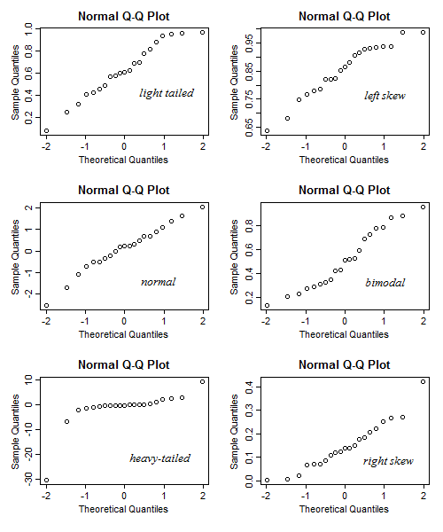

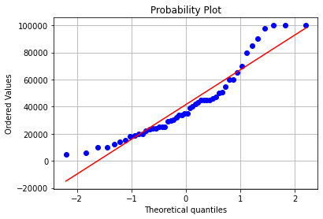

```python
# q-q plot for the data
stats.probplot(data['Mthly_HH_Income'], dist="norm", plot=plt)
plt.grid()
```

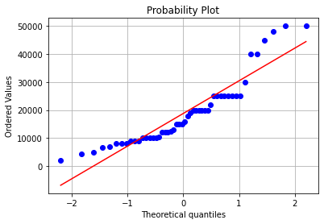

```python
stats.probplot(data['Mthly_HH_Expense'], dist="norm", plot=plt)
plt.grid()
```

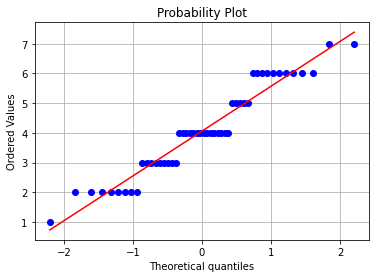

```python
stats.probplot(data['No_of_Fly_Members'], dist="norm", plot=plt)
plt.grid()
```

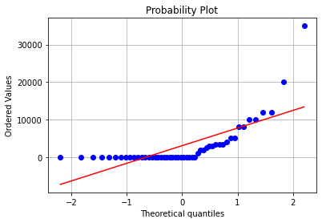

```python
stats.probplot(data['Emi_or_Rent_Amt'], dist="norm", plot=plt)
plt.grid()
```

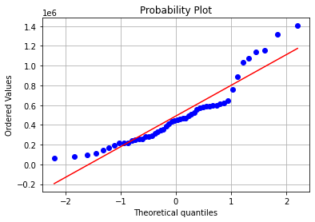

```python
stats.probplot(data['Annual_HH_Income'], dist="norm", plot=plt)
plt.grid()
```

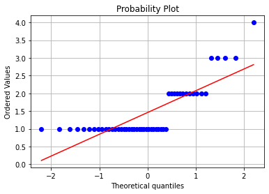

```python
stats.probplot(data['No_of_Earning_Members'], dist="norm", plot=plt)
plt.grid()
```

# Explain Box Cox and show the implementation of the same

A box-cox plot is used to convert the non-normally distributed dataset into the normally distributed dataset.

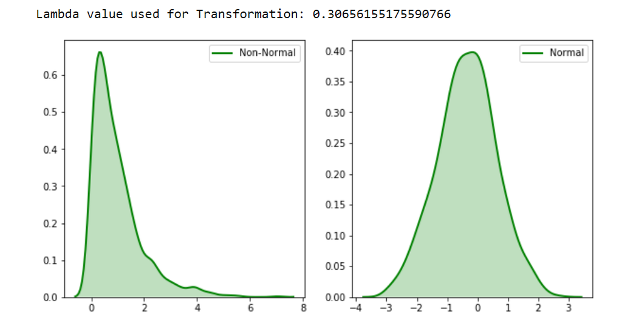

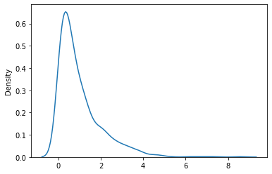

```python
import numpy as np
from scipy.stats import boxcox
import seaborn as sns

np.random.seed(0)

data = np.random.exponential(size=1000)

sns.distplot(data, hist=False, kde=True)
```

As the data is not normally distributed we are using BoxCox to transform it to normally distributed data

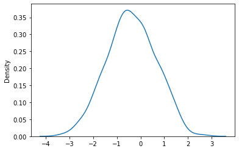

```python
#perform Box-Cox
transformed_data, best_lambda = boxcox(data)

#plot the distribution of the transformed data
sns.distplot(transformed_data, hist=False, kde=True)
```